# Pacific Salmon SAR & SAS Estimator

Smolt-adult survival (SAS) represents the survival of a release group when considering all of their possible fates. The “success” of a program will depend on how well the intended fate of those fish matches up with the observed proportion-at-fate. Here, we take release and return data from above and use these data collectively to calculate SAS as the number of fish that were recovered divided by the number released.

| Component | Term | Estimate | Std Error | t-value | p-value |  |
| --- | --- | --- | --- | --- | --- | --- |
| A. parametric coefficients | (Intercept) | -9.756 | 0.100 | -97.681 | 0.0000 | *** |
|  | fatehatchery | 2.835 | 0.106 | 26.857 | 0.0000 | *** |
|  | fatespawngr | 1.201 | 0.236 | 5.094 | 0.0000 | *** |
| Component | Term | edf | Ref. df | F-value | p-value |  |
| B. smooth terms | s(brood_year) | 3.846 | 10.000 | 1.197 | 0.0008 | *** |
|  | s(avg_weight) | 0.989 | 8.000 | 8.931 | 0.0000 | *** |
|  | te(jday,brood_year) | 7.229 | 15.000 | 2.641 | 0.0000 | *** |

Signif. codes: 0 <= '***' < 0.001 < '**' < 0.01 < '*' < 0.05  
Adjusted R-squared: 0.743, Deviance explained 0.821  
-REML : -659.523, Scale est: 62.301, N: 189

**Tab 1**

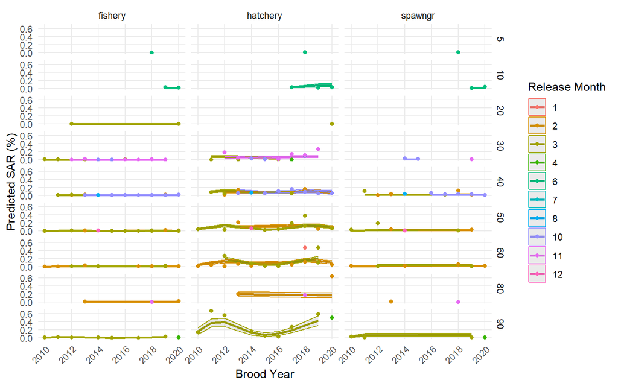

Figure 34: Predicted smolt-adult return generated from the model fit across fate, brood years, mean weight release groups, and release month.

**Tab 2**

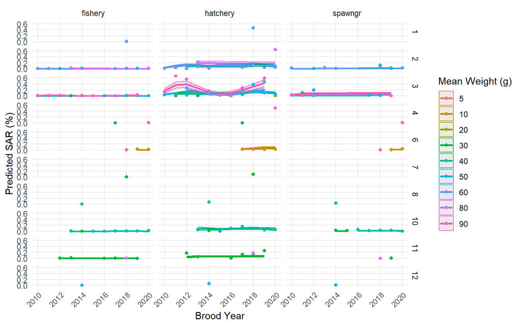

Figure 35: Predicted smolt-adult return generated from the model fit across fate, brood years, mean weight release groups, and release month.

**Tab 3**

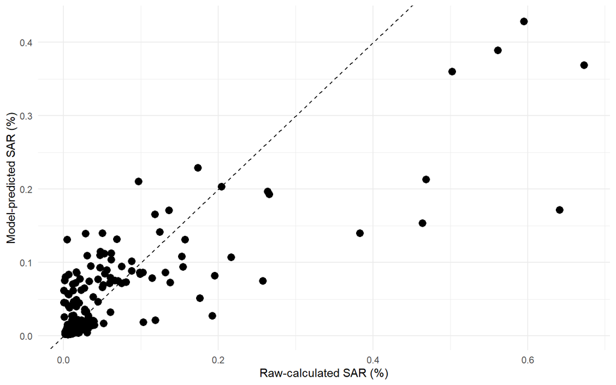

Figure 36: Raw-calculated vs. Model-predicted smolt-adult return generated from the model fit.

**Tab 4**

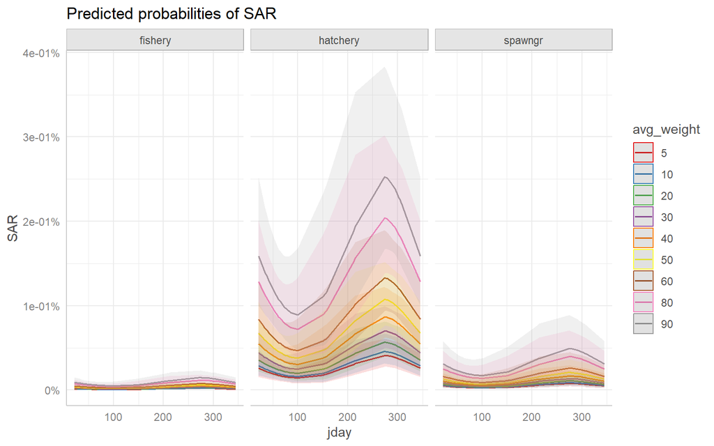

Figure 37: Marginal effects from the model fit showing how combined changes in mean weight at release and release timing (jday) affect smolt-adult-return across fates.

**Tab 1**

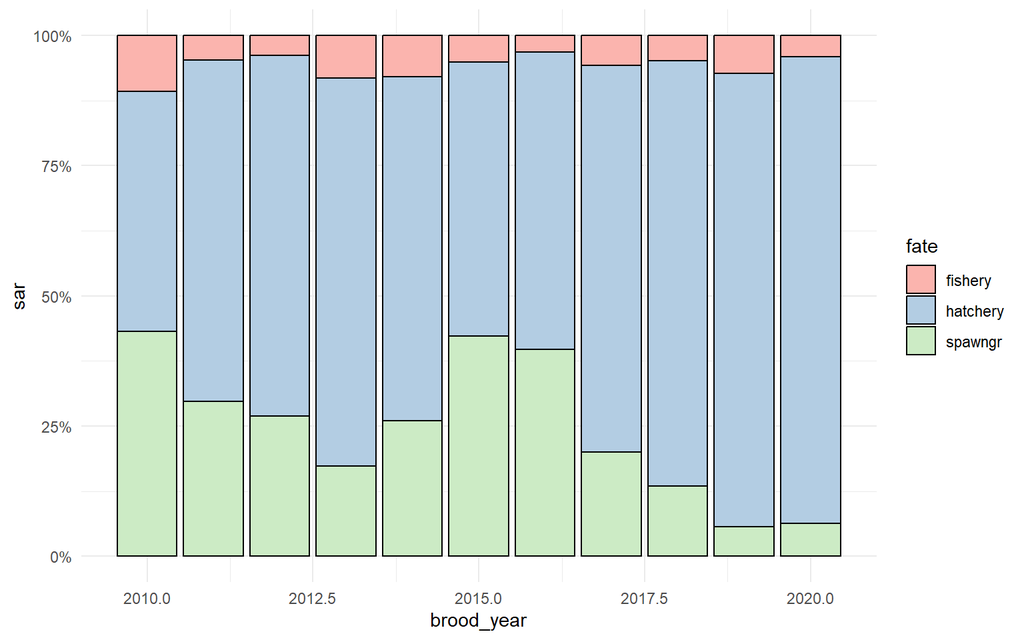

Figure 38: Proportion-at-fate of the calculated smolt-adult-return across brood years.

**Tab 2**

Smolt-adult-return (SAR)

Smolt-adult-return is calculated for each categorized fate (hatchery, fishery, and spawning ground) of paired release-recovery data. Below, fate is categorized based on fishery coding, and then fate-specific SARs are reported. These fate-specific SARs are then used below to: (1) fit predictive SAR models, and (2) calculate smolt-adult-survival (SAS). Fate is determined by the fishery coding reported for each recovery. Fishery codes range from 10-99, with some additional codes supplied for high seas fishery categories (800-812). We designate troll (10-19), net & seine (20-29), aboriginal (30-39), sport (40-49), treaty subsitence (56), test (60-69), and high seas (80-89, 800, 802-805, 812) fisheries recoveries as ‘fishery’ fates. In addition, we designate hatchery (50), fish trap (52), broodstock collections (53), and mixed broodstock collection/hatchery returns (57) recoveies as ‘hatchery’ fates, and we designate spawning ground (54) recoveries as ‘spawngr’ fates.

Paired release-recovery data are filtered for fates in this section, and used to calculate fate-specific SARs. We first report the recovery_location_codes present in the filtered data and the estimated recoveries (number_cwt_estimated) for each recovery location. There will likely be strays present, but we want to report a ‘return to rack’ for the hatchery to inform program performance and broodstock collection. Therefore, we filter these stray fish out here, and will re-incorporate them later in the summation of fate-specific SARs for calculation of SAS. Therefore, all hatchery SAR results will be for the list of location_codes categorized as hatchery_location_code in the metadata ruleset (Table 1). Hatcheries will often vary their rearing treatments to produce fish of different sizes at release or to release fish at different times of the season. Here, we aggregate the filtered hatchery data by the treatment variables size-at-release, release month, release site, and julian day of release. Below we report the SAR values shown in the figures above so the reader has access to the individual data points. Note that the figures report SAR in percentages, while the table values are raw values.

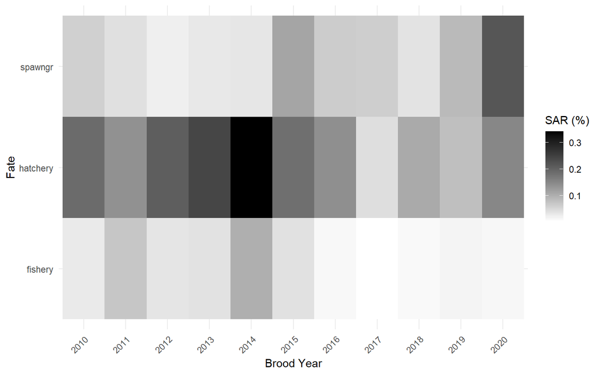

Figure 40: Smolt-adult return calculated collectively across brood year released and recovery fate.

**Tab 1**

Table 16: Recovery locations associated with a ‘hatchery’ fate in the filtered data, and the number of estimated recoveries (number_cwt_estimated) reported for each recovery location.

| recovery_location_code | name | latitude | longitude | psc_region | number_cwt_estimated |
| --- | --- | --- | --- | --- | --- |
| 3F10511^^100031^H01 | WHITE RIVER HATCHERY | 47.1716 | -122.0014 | MPS | 9530.87 |
| 3F10513^^150048^H | MINTER CR HATCHERY | 47.3726 | -122.7026 | SPS | 807.33 |
| 3F10806^^180272^H | ELWHA HATCHERY | 48.1152 | -123.5493 | JUAN | 21.04 |
| 3F10511^^100027^H01 | CLARKS CRK HATCHERY | 47.2048 | -122.3442 | MPS | 9.70 |
| 3F21902^^240356^H | FORKS CREEK HATCHERY | 46.5580 | -123.5948 | WILP | 6.00 |
| 3F10308^^070943^H | WALLACE R HATCHERY | 47.8674 | -121.7170 | NPS | 4.04 |
| 3F10806^^180274^H | LOWER ELWHA HATCHERY | 48.1277 | -123.5527 | JUAN | 2.00 |
| 3F10510^^150299^H | GROVERS CR HATCHERY | 47.7699 | -122.5590 | MPS | 1.03 |
| 3F10208^^031421^H | MARBLEMOUNT HATCHERY | 48.5223 | -121.4178 | SKAG | 1.01 |
| 3F10412^^160005^H | GEORGE ADAMS HATCHERY | 47.3013 | -123.1818 | HOOD | 1.00 |
| 3F10510^^090001^R10 | GREEN R TRAP@ HH DAM | NA | NA | MPS | 1.00 |
| 3F10806^^180185^H | MORSE CREEK HATCHERY | 48.0402 | -123.3480 | JUAN | 0.00 |

**Tab 2**

Table 17: Recovery locations associated with a ‘spawngr’ fate in the filtered data, and the number of estimated recoveries (number_cwt_estimated) reported for each recovery location.

| recovery_location_code | name | latitude | longitude | psc_region | number_cwt_estimated |
| --- | --- | --- | --- | --- | --- |
| 3F10806^^180018^R | DUNGENESS R 18.0018 | 48.1508 | -123.1331 | JUAN | 2990.51 |
| 3F10806^^180272^R | ELWHA R 18.0272 | 48.1507 | -123.5577 | JUAN | 107.45 |
| 3F10510^^090001^R02 | GREEN R 09.0001 | 47.4752 | -122.2505 | MPS | 96.10 |
| 3F10511^^100429^R | S PRAIRIE CR 10.0429 | 47.0981 | -122.1544 | MPS | 80.12 |
| 3F10511^^100057^R | BOISE CR 10.0057 | 47.1750 | -122.0177 | MPS | 49.68 |
| 3F10308^^070940^R | WALLACE R 07.0940 | 47.8591 | -121.7938 | NPS | 12.00 |
| 3F10806^^180048^R | GRAY WOLF R 18.0048 | 47.9767 | -123.1105 | JUAN | 9.28 |
| 3F10510^^090114^R | NEWAUKUM CR 09.0114 | 47.2853 | -122.0671 | MPS | 6.18 |
| 3F10511^^100432^R | WILKESON CR 10.0432 | 47.1356 | -122.0748 | MPS | 2.02 |
| 3F10806^^180185^R | MORSE CR 18.0185 | 48.1176 | -123.3496 | JUAN | 1.00 |
| 3F10412^^160001^R | SKOKOMISH R 16.0001 | 47.3387 | -123.1163 | HOOD | 0.00 |
| 3F10412^^160001^R02 | SKOKOMISH R -NF (16) | 47.3154 | -123.2376 | HOOD | 0.00 |
| 3F10412^^160011^R | SKOKOMISH-SF 16.0011 | 47.3170 | -123.2525 | HOOD | 0.00 |

**Tab 3**

Table 18: Recovery locations associated with a ‘fishery’ fate in the filtered data, and the number of estimated recoveries (number_cwt_estimated) reported for each recovery location.

| recovery_location_code | name | latitude | longitude | psc_region | number_cwt_estimated |
| --- | --- | --- | --- | --- | --- |
| 3F10511^^100021^R | PUYALLUP R 10.0021 | 47.2685 | -122.4252 | MPS | 787.82 |
| 3F10511^^100031^R | WHITE R 10.0031 | 47.1997 | -122.2573 | MPS | 330.16 |
| 3M32404 | MARINE AREA 4 | NA | NA | NWC | 179.26 |
| 3M32404^^B | 4B -TREATY TROLL | NA | NA | JUAN | 87.90 |
| 2MS01M403^^^^^^^000 | NWTR M403-000 | NA | NA | NA | 81.32 |
| 2MS02P123^^^^^^^000 | SWTR P123-000 | NA | NA | NA | 61.86 |
| 3M32303 | MARINE AREA 3 | NA | NA | NWC | 44.47 |
| 2MS01P127^^^^^^^000 | NWTR P127-000 | NA | NA | NA | 43.97 |
| 2MS02M23B^^^^^^^000 | SWTR M23B-000 | NA | NA | NA | 39.53 |
| 3M11105^^872465 | SEKIU | NA | NA | JUAN | 37.04 |
| 2MS5SP024^^^^^^^000 | 5NWCVIS P024-000 | NA | NA | NA | 34.85 |
| 2MN06P101^^^^^^^000 | NTR P101-000 | NA | NA | NA | 33.65 |
| 3M11106^^872402 | PORT ANGELES -OUTER | NA | NA | JUAN | 30.25 |
| 2MS24P020WHIR^BY^05 | JFSPT WHIR BY(20-5) | 48.3114 | -123.5733 | NA | 25.79 |
| 2MS5SP124^^^^^^^000 | 5NWCVIS P124-000 | NA | NA | NA | 23.91 |
| 2MS24M19BVICTORI^01 | 24 M19B VICTORI(19-1) | 48.4211 | -123.3928 | NA | 23.55 |
| 2MS24P020BEDF^IS^05 | JFSPT BEDF IS(20-5) | 48.3144 | -123.6044 | NA | 23.11 |
| 3M11411^^872563 | POINT DEFIANCE LIGHT | 47.3181 | -122.5450 | MPS | 19.74 |
| 3M32404^^860074 | OCEAN SPORT AREA 74 | NA | NA | NWC | 18.89 |
| 3M32202 | MARINE AREA 2 | NA | NA | GRAY | 16.04 |
| 3M11309^^872365 | PILOT POINT | 47.8808 | -122.5130 | MPS | 16.04 |
| 2MS24P020OTTE^PT^05 | JFSPT OTTE PT(20-5) | 48.3569 | -123.8222 | NA | 14.77 |
| 2MSSVP123LONG^BE | SWVISPLONG BE(P123) | 49.0360 | -125.7428 | NA | 14.33 |
| 3M11107^^872436 | REEF POINT CYPRESS | NA | NA | NOWA | 13.89 |
| 2MS24P020SOOKE^^^07 | JFSPT SOOKE(20-7) | 48.3828 | -123.7319 | NA | 13.68 |
| 2MS24P020CMPR^BY^05 | JFSPT CMPR BY(20-5) | 48.5561 | -124.5522 | NA | 13.59 |
| 2MS02M111^^^^^^^000 | SWTR M111-000 | NA | NA | NA | 13.00 |
| 2MN06P001^^^^^^^000 | NTR P001-000 | NA | NA | NA | 12.26 |
| 3M11413^^872558 | WOLLOCHET BAY | NA | NA | SPS | 12.00 |
| 3M11107^^872513 | THATCHER PASS | NA | NA | NOWA | 11.13 |

[output cut: 93 more lines]

**Tab A**

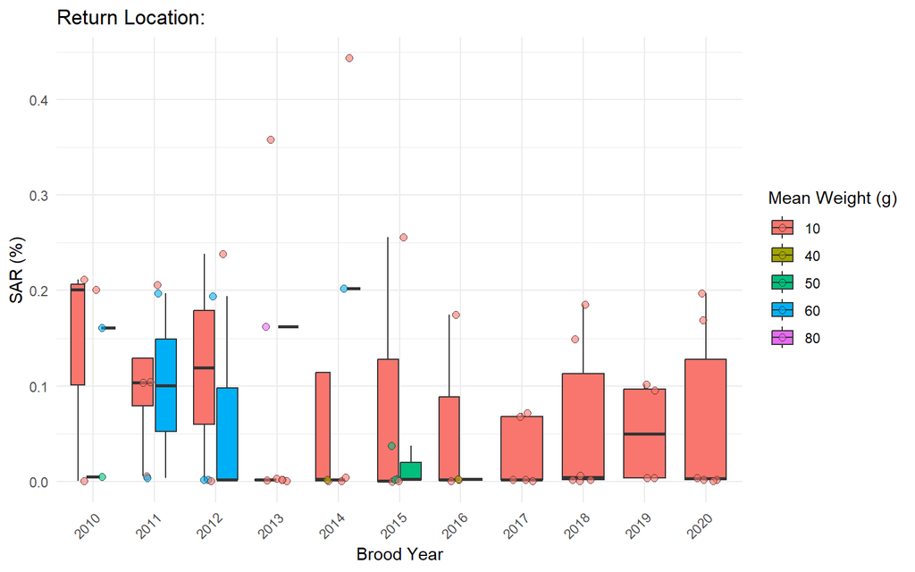

Figure 41: Smolt-adult return calcualted from the raw release and return data across brood years and mean weight release groups.

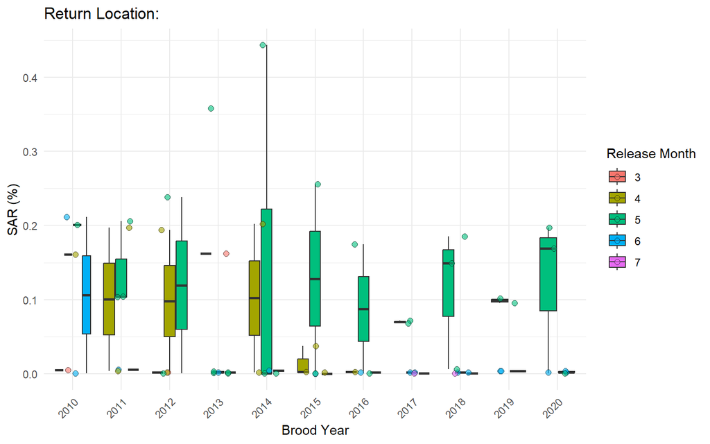

Figure 42: Smolt-adult return calcualted from the raw release and return data across brood years and release month.

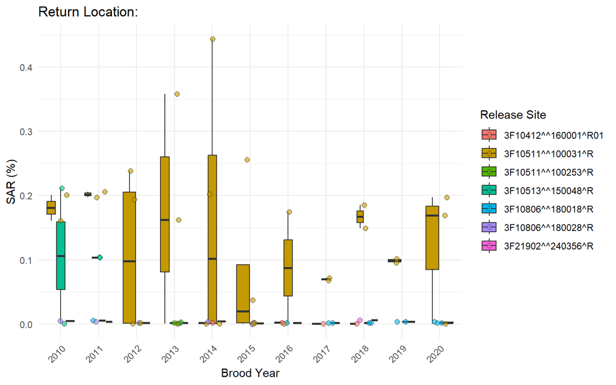

Figure 43: Smolt-adult return calcualted from the raw release and return data across brood years and release sites.

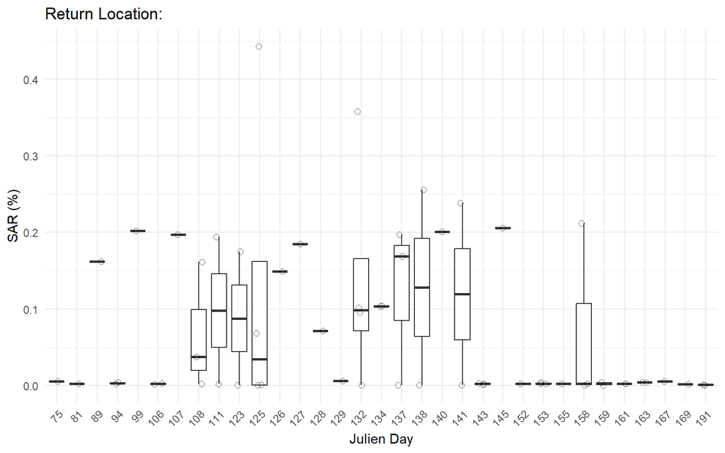

Figure 44: Smolt-adult return calcualted from the raw release and return data across brood years and julian days.

**Tab B**

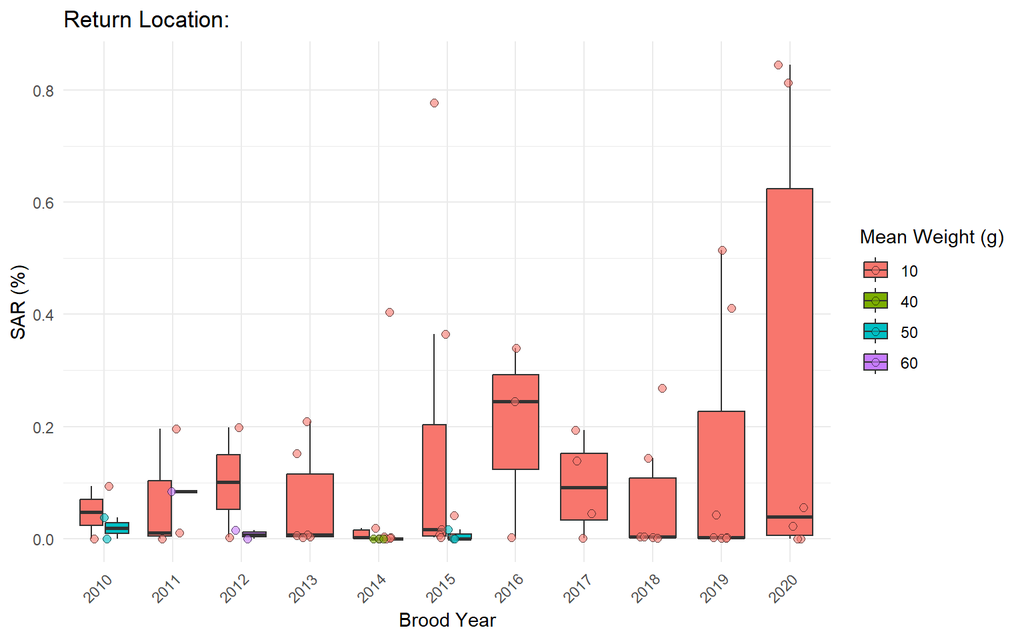

Figure 45: Smolt-adult return calcualted from the raw release and return data across brood years and mean weight release groups.

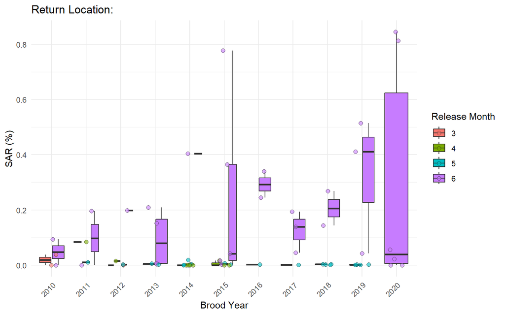

Figure 46: Smolt-adult return calcualted from the raw release and return data across brood years and release month.

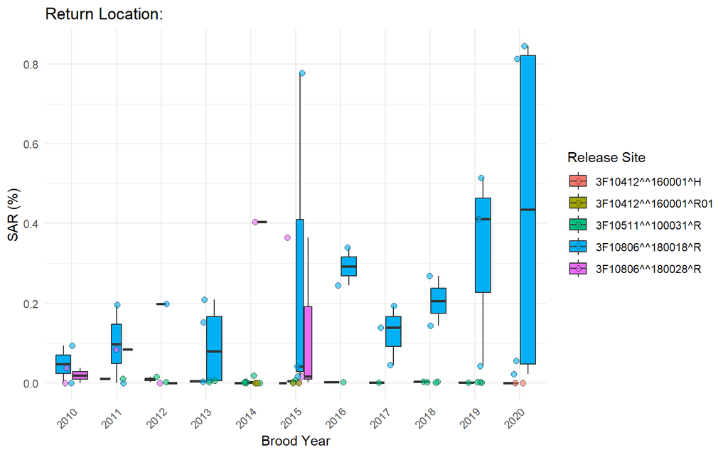

Figure 47: Smolt-adult return calcualted from the raw release and return data across brood years and release sites.

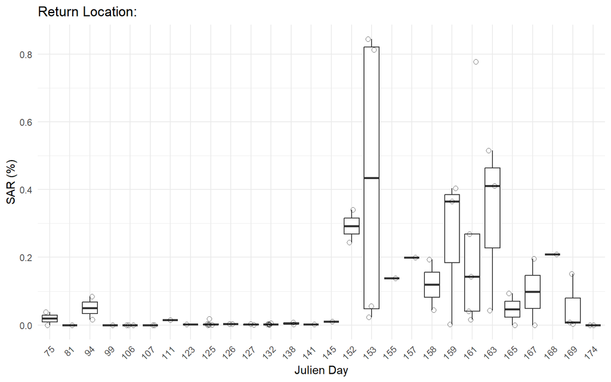

Figure 48: Smolt-adult return calcualted from the raw release and return data across brood years and julian days.

**Tab C**

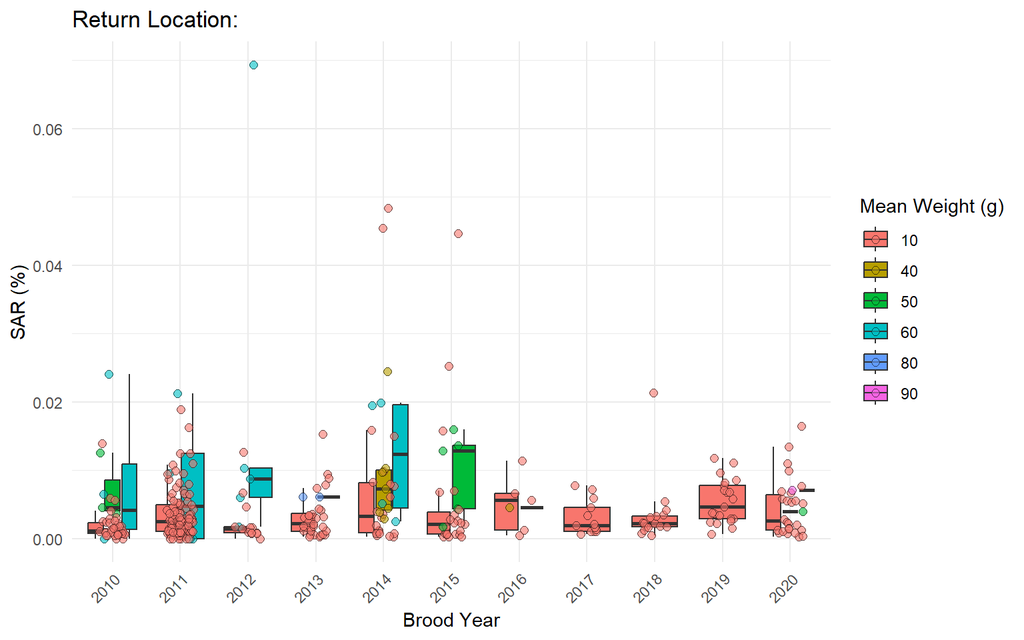

Figure 49: Smolt-adult return calcualted from the raw release and return data across brood years and mean weight release groups.

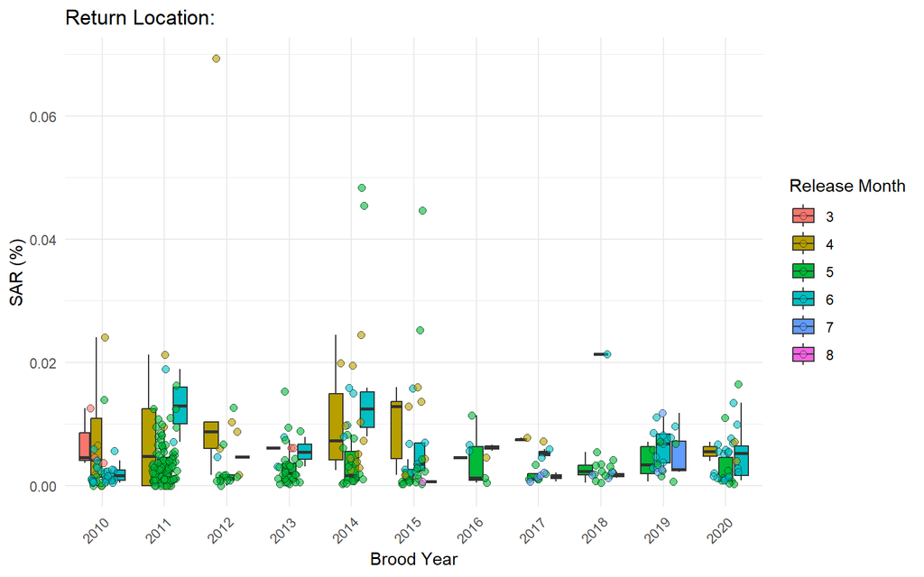

Figure 50: Smolt-adult return calcualted from the raw release and return data across brood years and release month.

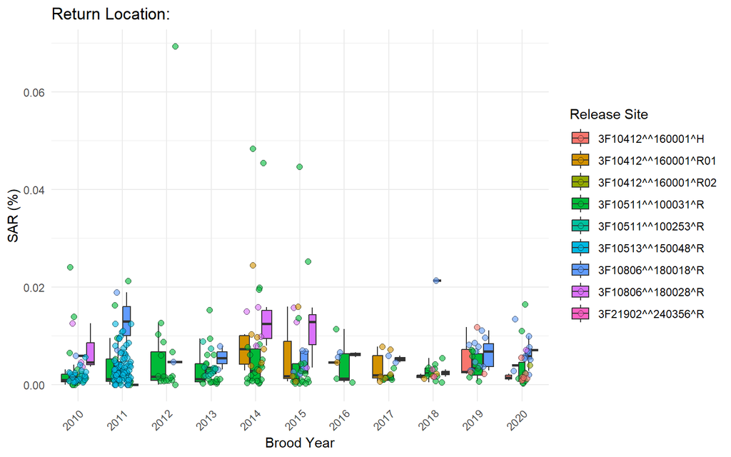

Figure 51: Smolt-adult return calcualted from the raw release and return data across brood years and release sites.

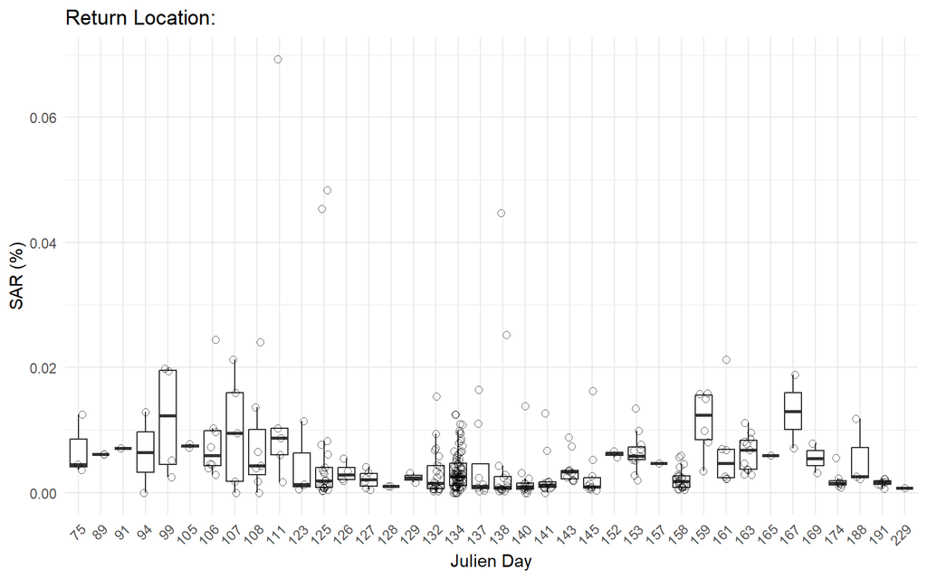

Figure 52: Smolt-adult return calcualted from the raw release and return data across brood years and julian days.

**Tab A**

Table 19: Smolt-adult return calculated across brood years, mean weight-at-release, and time at release.

| species | release_location_code | recovery_location_code | month | jday | avg_weight | event_released | sar |
| --- | --- | --- | --- | --- | --- | --- | --- |
| **2010** |  |  |  |  |  |  |  |
| 1 | 3F10806^^180028^R | 3F10806^^180272^H | 3 | 75 | 50 | 39931 | 0.0000508 |
| 1 | 3F10511^^100031^R | 3F10511^^100031^H01 | 4 | 108 | 60 | 57090 | 0.0016115 |
| 1 | 3F10511^^100031^R | 3F10511^^100031^H01 | 5 | 140 | 10 | 353644 | 0.0020105 |
| 1 | 3F10513^^150048^R | 3F10510^^150299^H | 6 | 158 | 10 | 224794 | 0.0000046 |
| 1 | 3F10513^^150048^R | 3F10513^^150048^H | 6 | 158 | 10 | 224794 | 0.0021177 |
| **2011** |  |  |  |  |  |  |  |
| 1 | 3F10806^^180028^R | 3F10806^^180272^H | 4 | 94 | 60 | 51985 | 0.0000385 |
| 1 | 3F10511^^100031^R | 3F10511^^100031^H01 | 4 | 107 | 60 | 55772 | 0.0019732 |
| 1 | 3F10511^^100031^R | 3F10511^^100031^H01 | 5 | 145 | 10 | 336665 | 0.0020588 |
| 1 | 3F10513^^150048^R | 3F10513^^150048^H | 5 | 134 | 10 | 207039 | 0.0010392 |
| 1 | 3F10513^^150048^R | 3F10513^^150048^H | 5 | 134 | 10 | 109398 | 0.0010340 |
| 1 | 3F10806^^180018^R | 3F10806^^180272^H | 6 | 167 | 10 | 54104 | 0.0000556 |
| **2012** |  |  |  |  |  |  |  |
| 1 | 3F10806^^180028^R | 3F10806^^180272^H | 3 | 81 | 60 | 50087 | 0.0000200 |
| 1 | 3F10511^^100031^R | 3F10208^^031421^H | 4 | 111 | 60 | 58297 | 0.0000173 |
| 1 | 3F10511^^100031^R | 3F10511^^100031^H01 | 4 | 111 | 60 | 58297 | 0.0019425 |
| 1 | 3F10511^^100031^R | 3F10308^^070943^H | 5 | 141 | 10 | 348625 | 0.0000029 |
| 1 | 3F10511^^100031^R | 3F10511^^100031^H01 | 5 | 141 | 10 | 348625 | 0.0023827 |
| **2013** |  |  |  |  |  |  |  |
| 1 | 3F10511^^100031^R | 3F10511^^100031^H01 | 3 | 89 | 80 | 32705 | 0.0016205 |
| 1 | 3F10511^^100031^R | 3F10511^^100027^H01 | 5 | 132 | 10 | 344107 | 0.0000029 |
| 1 | 3F10511^^100031^R | 3F10511^^100031^H01 | 5 | 132 | 10 | 344107 | 0.0035805 |
| 1 | 3F10511^^100253^R | 3F10511^^100027^H01 | 5 | 143 | 10 | 103031 | 0.0000297 |
| 1 | 3F10511^^100253^R | 3F10511^^100031^H01 | 5 | 143 | 10 | 103031 | 0.0000194 |
| 1 | 3F10806^^180018^R | 3F10806^^180272^H | 6 | 169 | 10 | 55888 | 0.0000179 |
| **2014** |  |  |  |  |  |  |  |
| 1 | 3F10412^^160001^R01 | 3F10412^^160005^H | 4 | 106 | 40 | 63507 | 0.0000157 |
| 1 | 3F10511^^100031^R | 3F10511^^100031^H01 | 4 | 99 | 60 | 45016 | 0.0020242 |
| 1 | 3F10511^^100031^R | 3F10308^^070943^H | 5 | 125 | 10 | 346217 | 0.0000058 |
| 1 | 3F10511^^100031^R | 3F10511^^100027^H01 | 5 | 125 | 10 | 346217 | 0.0000073 |
| 1 | 3F10511^^100031^R | 3F10511^^100031^H01 | 5 | 125 | 10 | 346217 | 0.0044353 |
| 1 | 3F10806^^180028^R | 3F10806^^180272^H | 6 | 159 | 10 | 23303 | 0.0000429 |
| **2015** |  |  |  |  |  |  |  |
| 1 | 3F10806^^180028^R | 3F10806^^180272^H | 4 | 94 | 50 | 46785 | 0.0000214 |
| 1 | 3F10511^^100031^R | 3F10511^^100027^H01 | 4 | 108 | 50 | 50696 | 0.0000199 |
| 1 | 3F10511^^100031^R | 3F10511^^100031^H01 | 4 | 108 | 50 | 50696 | 0.0003748 |
| 1 | 3F10511^^100031^R | 3F10511^^100027^H01 | 5 | 138 | 10 | 348586 | 0.0000029 |
| 1 | 3F10511^^100031^R | 3F10511^^100031^H01 | 5 | 138 | 10 | 348586 | 0.0025589 |
| **2016** |  |  |  |  |  |  |  |
| 1 | 3F10412^^160001^R01 | 3F10513^^150048^H | 4 | 106 | 40 | 38792 | 0.0000258 |
| 1 | 3F10511^^100031^R | 3F10308^^070943^H | 5 | 123 | 10 | 355921 | 0.0000029 |
| 1 | 3F10511^^100031^R | 3F10511^^100031^H01 | 5 | 123 | 10 | 355921 | 0.0017476 |
| 1 | 3F10806^^180018^R | 3F10806^^180272^H | 6 | 152 | 10 | 49263 | 0.0000203 |
| **2017** |  |  |  |  |  |  |  |
| 1 | 3F10511^^100031^R | 3F10511^^100031^H01 | 5 | 128 | 10 | 197032 | 0.0007156 |
| 1 | 3F10511^^100031^R | 3F10511^^100031^H01 | 5 | 125 | 10 | 202296 | 0.0006822 |
| 1 | 3F10806^^180018^R | 3F10806^^180272^H | 6 | 155 | 10 | 50180 | 0.0000199 |
| 1 | 3F10806^^180018^R | 3F10806^^180272^H | 6 | 158 | 10 | 49107 | 0.0000204 |
| 1 | 3F10412^^160001^R01 | 3F10513^^150048^H | 7 | 191 | 10 | 156045 | 0.0000065 |
| **2018** |  |  |  |  |  |  |  |
| 1 | 3F10511^^100031^R | 3F10511^^100031^H01 | 5 | 126 | 10 | 199613 | 0.0014879 |
| 1 | 3F10511^^100031^R | 3F10511^^100031^H01 | 5 | 127 | 10 | 259365 | 0.0018507 |
| 1 | 3F21902^^240356^R | 3F21902^^240356^H | 5 | 129 | 10 | 100138 | 0.0000599 |
| 1 | 3F10806^^180018^R | 3F10513^^150048^H | 6 | 161 | 10 | 49674 | 0.0000201 |
| 1 | 3F10806^^180018^R | 3F10806^^180272^H | 6 | 161 | 10 | 49674 | 0.0000201 |
| 1 | 3F10412^^160001^R01 | 3F10511^^100031^H01 | 7 | 191 | 10 | 123376 | 0.0000081 |
| **2019** |  |  |  |  |  |  |  |
| 1 | 3F10511^^100031^R | 3F10511^^100031^H01 | 5 | 132 | 10 | 286663 | 0.0009523 |
| 1 | 3F10511^^100031^R | 3F10511^^100031^H01 | 5 | 132 | 10 | 200557 | 0.0010172 |
| 1 | 3F10806^^180018^R | 3F10806^^180272^H | 6 | 163 | 10 | 51991 | 0.0000385 |
| 1 | 3F10806^^180018^R | 3F10806^^180272^H | 6 | 163 | 10 | 51696 | 0.0000387 |
| **2020** |  |  |  |  |  |  |  |
| 1 | 3F10511^^100031^R | 3F10511^^100027^H01 | 5 | 137 | 10 | 360109 | 0.0000030 |
| 1 | 3F10511^^100031^R | 3F10511^^100031^H01 | 5 | 137 | 10 | 360109 | 0.0016912 |
| 1 | 3F10511^^100031^R | 3F10511^^100031^H01 | 5 | 137 | 10 | 198329 | 0.0019715 |
| 1 | 3F10806^^180018^R | 3F10806^^180272^H | 6 | 153 | 10 | 49901 | 0.0000200 |
| 1 | 3F10806^^180018^R | 3F10806^^180272^H | 6 | 153 | 10 | 51260 | 0.0000195 |
| 1 | 3F10806^^180018^R | 3F10806^^180274^H | 6 | 153 | 10 | 51260 | 0.0000390 |

**Tab B**

Table 20: Smolt-adult return calculated across brood years, mean weight-at-release, and time at release.

| species | release_location_code | recovery_location_code | month | jday | avg_weight | event_released | sar |
| --- | --- | --- | --- | --- | --- | --- | --- |
| **2010** |  |  |  |  |  |  |  |
| 1 | 3F10806^^180028^R | 3F10806^^180018^R | 3 | 75 | 50 | 39931 | 0.0003797 |
| 1 | 3F10806^^180028^R | 3F10806^^180185^R | 3 | 75 | 50 | 39931 | 0.0000000 |
| 1 | 3F10806^^180018^R | 3F10806^^180018^R | 6 | 165 | 10 | 27387 | 0.0009369 |
| 1 | 3F10806^^180018^R | 3F10806^^180185^R | 6 | 165 | 10 | 27387 | 0.0000000 |
| **2011** |  |  |  |  |  |  |  |
| 1 | 3F10806^^180028^R | 3F10806^^180018^R | 4 | 94 | 60 | 51985 | 0.0008429 |
| 1 | 3F10511^^100031^R | 3F10511^^100429^R | 5 | 145 | 10 | 336665 | 0.0001019 |
| 1 | 3F10806^^180018^R | 3F10806^^180018^R | 6 | 167 | 10 | 54104 | 0.0019570 |
| 1 | 3F10806^^180018^R | 3F10806^^180185^R | 6 | 167 | 10 | 54104 | 0.0000000 |
| **2012** |  |  |  |  |  |  |  |
| 1 | 3F10806^^180028^R | 3F10806^^180185^R | 3 | 81 | 60 | 50087 | 0.0000000 |
| 1 | 3F10511^^100031^R | 3F10511^^100429^R | 4 | 111 | 60 | 58297 | 0.0001492 |
| 1 | 3F10511^^100031^R | 3F10511^^100429^R | 5 | 141 | 10 | 348625 | 0.0000250 |
| 1 | 3F10806^^180018^R | 3F10806^^180018^R | 6 | 157 | 10 | 51340 | 0.0019873 |
| **2013** |  |  |  |  |  |  |  |
| 1 | 3F10511^^100031^R | 3F10510^^090001^R02 | 5 | 132 | 10 | 344107 | 0.0000559 |
| 1 | 3F10511^^100031^R | 3F10511^^100429^R | 5 | 132 | 10 | 344107 | 0.0000253 |
| 1 | 3F10806^^180018^R | 3F10806^^180018^R | 6 | 169 | 10 | 55888 | 0.0015161 |
| 1 | 3F10806^^180018^R | 3F10806^^180048^R | 6 | 169 | 10 | 55888 | 0.0000308 |
| 1 | 3F10806^^180018^R | 3F10806^^180272^R | 6 | 169 | 10 | 55888 | 0.0000735 |
| 1 | 3F10806^^180018^R | 3F10806^^180018^R | 6 | 168 | 10 | 4968 | 0.0020874 |
| **2014** |  |  |  |  |  |  |  |
| 1 | 3F10412^^160001^R01 | 3F10412^^160001^R | 4 | 106 | 40 | 63507 | 0.0000000 |
| 1 | 3F10412^^160001^R01 | 3F10412^^160001^R02 | 4 | 106 | 40 | 58976 | 0.0000000 |
| 1 | 3F10412^^160001^R01 | 3F10412^^160011^R | 4 | 106 | 40 | 58976 | 0.0000000 |
| 1 | 3F10511^^100031^R | 3F10511^^100057^R | 4 | 99 | 60 | 45016 | 0.0000000 |
| 1 | 3F10511^^100031^R | 3F10308^^070940^R | 5 | 125 | 10 | 346217 | 0.0000347 |
| 1 | 3F10511^^100031^R | 3F10510^^090001^R02 | 5 | 125 | 10 | 346217 | 0.0001868 |
| 1 | 3F10511^^100031^R | 3F10510^^090114^R | 5 | 125 | 10 | 346217 | 0.0000179 |
| 1 | 3F10511^^100031^R | 3F10511^^100057^R | 5 | 125 | 10 | 346217 | 0.0000000 |
| 1 | 3F10511^^100031^R | 3F10511^^100429^R | 5 | 125 | 10 | 346217 | 0.0000129 |
| 1 | 3F10806^^180028^R | 3F10806^^180018^R | 6 | 159 | 10 | 23303 | 0.0040355 |
| **2015** |  |  |  |  |  |  |  |
| 1 | 3F10806^^180028^R | 3F10806^^180018^R | 4 | 94 | 50 | 46785 | 0.0001616 |
| 1 | 3F10412^^160001^R01 | 3F10412^^160001^R | 4 | 107 | 50 | 59261 | 0.0000000 |
| 1 | 3F10412^^160001^R01 | 3F10412^^160001^R02 | 4 | 107 | 50 | 59261 | 0.0000000 |
| 1 | 3F10511^^100031^R | 3F10511^^100057^R | 5 | 138 | 10 | 348586 | 0.0000754 |
| 1 | 3F10511^^100031^R | 3F10511^^100429^R | 5 | 138 | 10 | 348586 | 0.0000219 |
| 1 | 3F10806^^180028^R | 3F10806^^180018^R | 6 | 159 | 10 | 50353 | 0.0036530 |
| 1 | 3F10806^^180028^R | 3F10806^^180185^R | 6 | 159 | 10 | 50353 | 0.0000199 |
| 1 | 3F10806^^180018^R | 3F10806^^180018^R | 6 | 161 | 10 | 47500 | 0.0077752 |
| 1 | 3F10806^^180018^R | 3F10806^^180048^R | 6 | 161 | 10 | 47500 | 0.0001592 |
| 1 | 3F10806^^180018^R | 3F10806^^180272^R | 6 | 161 | 10 | 47500 | 0.0004126 |
| **2016** |  |  |  |  |  |  |  |
| 1 | 3F10511^^100031^R | 3F10510^^090001^R02 | 5 | 123 | 10 | 355921 | 0.0000171 |
| 1 | 3F10806^^180018^R | 3F10806^^180018^R | 6 | 152 | 10 | 49532 | 0.0024413 |
| 1 | 3F10806^^180018^R | 3F10806^^180018^R | 6 | 152 | 10 | 49263 | 0.0034009 |
| **2017** |  |  |  |  |  |  |  |
| 1 | 3F10511^^100031^R | 3F10511^^100057^R | 5 | 125 | 10 | 202296 | 0.0000087 |
| 1 | 3F10806^^180018^R | 3F10806^^180018^R | 6 | 155 | 10 | 50180 | 0.0013842 |
| 1 | 3F10806^^180018^R | 3F10806^^180018^R | 6 | 158 | 10 | 49107 | 0.0019337 |
| 1 | 3F10806^^180018^R | 3F10806^^180272^R | 6 | 158 | 10 | 49107 | 0.0004456 |
| **2018** |  |  |  |  |  |  |  |
| 1 | 3F10511^^100031^R | 3F10510^^090001^R02 | 5 | 126 | 10 | 199613 | 0.0000305 |
| 1 | 3F10511^^100031^R | 3F10511^^100057^R | 5 | 126 | 10 | 199613 | 0.0000351 |
| 1 | 3F10511^^100031^R | 3F10511^^100057^R | 5 | 127 | 10 | 259365 | 0.0000270 |
| 1 | 3F10511^^100031^R | 3F10511^^100432^R | 5 | 127 | 10 | 259365 | 0.0000078 |
| 1 | 3F10806^^180018^R | 3F10806^^180018^R | 6 | 161 | 10 | 49674 | 0.0026823 |
| 1 | 3F10806^^180018^R | 3F10806^^180018^R | 6 | 161 | 10 | 30618 | 0.0014345 |
| **2019** |  |  |  |  |  |  |  |
| 1 | 3F10511^^100031^R | 3F10511^^100057^R | 5 | 132 | 10 | 286663 | 0.0000142 |
| 1 | 3F10511^^100031^R | 3F10511^^100429^R | 5 | 132 | 10 | 286663 | 0.0000196 |
| 1 | 3F10511^^100031^R | 3F10511^^100057^R | 5 | 132 | 10 | 200557 | 0.0000179 |
| 1 | 3F10511^^100031^R | 3F10511^^100429^R | 5 | 132 | 10 | 200557 | 0.0000101 |
| 1 | 3F10806^^180018^R | 3F10806^^180018^R | 6 | 163 | 10 | 51991 | 0.0041099 |
| 1 | 3F10806^^180018^R | 3F10806^^180018^R | 6 | 163 | 10 | 51696 | 0.0051509 |
| 1 | 3F10806^^180018^R | 3F10806^^180272^R | 6 | 163 | 10 | 51696 | 0.0004290 |
| **2020** |  |  |  |  |  |  |  |
| 1 | 3F10806^^180018^R | 3F10806^^180018^R | 6 | 153 | 10 | 49901 | 0.0084463 |
| 1 | 3F10806^^180018^R | 3F10806^^180272^R | 6 | 153 | 10 | 49901 | 0.0005627 |
| 1 | 3F10806^^180018^R | 3F10806^^180018^R | 6 | 153 | 10 | 51260 | 0.0081256 |
| 1 | 3F10806^^180018^R | 3F10806^^180272^R | 6 | 153 | 10 | 51260 | 0.0002263 |
| 1 | 3F10412^^160001^H | 3F10412^^160001^R | 6 | 174 | 10 | 300911 | 0.0000000 |
| 1 | 3F10412^^160001^H | 3F10412^^160001^R02 | 6 | 174 | 10 | 300911 | 0.0000000 |

**Tab C**

Table 21: Smolt-adult return calculated across brood years, mean weight-at-release, and time at release.

| species | release_location_code | recovery_location_code | month | jday | avg_weight | event_released | sar |
| --- | --- | --- | --- | --- | --- | --- | --- |
| **2010** |  |  |  |  |  |  |  |
| 1 | 3F10806^^180028^R | 3F10412^^160005^R | 3 | 75 | 50 | 39931 | 0.0000453 |
| 1 | 3F10806^^180028^R | 3F10513^^110008^R | 3 | 75 | 50 | 39931 | 0.0001255 |
| 1 | 3F10806^^180028^R | 3M10510^^E | 3 | 75 | 50 | 39931 | 0.0000366 |
| 1 | 3F10511^^100031^R | 3M11105^^872465 | 4 | 108 | 60 | 57090 | 0.0000657 |
| 1 | 3F10511^^100031^R | 3M11413^^872206 | 4 | 108 | 60 | 57090 | 0.0000175 |
| 1 | 3F10511^^100031^R | 3F10511^^100021^R | 4 | 108 | 60 | 57090 | 0.0002403 |
| 1 | 3F10511^^100031^R | 3F10511^^100031^R | 4 | 108 | 60 | 57090 | 0.0000000 |
| 1 | 3F10511^^100031^R | 3M11106^^872402 | 5 | 140 | 10 | 353644 | 0.0000223 |
| 1 | 3F10511^^100031^R | 3M11106^^872557 | 5 | 140 | 10 | 353644 | 0.0000079 |
| 1 | 3F10511^^100031^R | 3M11411^^872563 | 5 | 140 | 10 | 353644 | 0.0000000 |
| 1 | 3F10511^^100031^R | 3F10511^^100021^R | 5 | 140 | 10 | 353644 | 0.0001390 |
| 1 | 3F10511^^100031^R | 3F10511^^100031^R | 5 | 140 | 10 | 353644 | 0.0000000 |
| 1 | 3F10511^^100031^R | 2MS24M19BMACC^PT^01 | 5 | 140 | 10 | 353644 | 0.0000311 |
| 1 | 3F10511^^100031^R | 2MS24P020OTTE^PT^05 | 5 | 140 | 10 | 353644 | 0.0000150 |
| 1 | 3F10511^^100031^R | 2MS02P123^^^^^^^000 | 5 | 140 | 10 | 353644 | 0.0000105 |
| 1 | 3F10511^^100031^R | 3M32303 | 5 | 140 | 10 | 353644 | 0.0000043 |
| 1 | 3F10511^^100031^R | 3M32404 | 5 | 140 | 10 | 353644 | 0.0000097 |
| 1 | 3F10511^^100031^R | 3M32404 | 5 | 140 | 10 | 353644 | 0.0000138 |
| 1 | 3F10511^^100031^R | 3M32303 | 5 | 140 | 10 | 353644 | 0.0000049 |
| 1 | 3F10511^^100031^R | 3M32404 | 5 | 140 | 10 | 353644 | 0.0000085 |
| 1 | 3F10511^^100031^R | 3M32404^^B | 5 | 140 | 10 | 353644 | 0.0000066 |
| 1 | 3F10806^^180018^R | 2MS01P127^^^^^^^000 | 6 | 165 | 10 | 27387 | 0.0000592 |
| 1 | 3F10513^^150048^R | 3M11105^^872465 | 6 | 158 | 10 | 224794 | 0.0000167 |
| 1 | 3F10513^^150048^R | 3M11106^^872402 | 6 | 158 | 10 | 224794 | 0.0000099 |
| 1 | 3F10513^^150048^R | 3M11107^^872211 | 6 | 158 | 10 | 224794 | 0.0000188 |
| 1 | 3F10513^^150048^R | 3M11107^^872436 | 6 | 158 | 10 | 224794 | 0.0000253 |
| 1 | 3F10513^^150048^R | 3M11410^^872300 | 6 | 158 | 10 | 224794 | 0.0000242 |
| 1 | 3F10513^^150048^R | 3M11411^^872088 | 6 | 158 | 10 | 224794 | 0.0000111 |
| 1 | 3F10513^^150048^R | 3M10510 | 6 | 158 | 10 | 224794 | 0.0000044 |

[output cut: 317 more lines]

SAR Model Fit

SAR time series are then fit to generalized additive models to summarize trends and identify any potentially significant release treatments. There are a variety of methods that can be employed for summarizing and forecasting SAR. A simple form of this would entail fitting a generalized additive model to the time series of SAR data. Here, we fit generalized additive models assuming a quasi-binomial family and a logit link function to the time series of two components of the smolt-adult-return data: total tags released & total tags lost. Models employed brood year, weight-at-release, and julian day as main effects (release stage, hatchery, & release location coming soon), as well as two-way interactions among these.After model fitting, figures are generated to show the results of the SAR calculations and the selected model fit, including marginal effects.

Smolt-adult survival (SAS) represents the survival of a release group when considering all of their possible fates. The “success” of a program will depend on how well the intended fate of those fish matches up with the observed proportion-at-fate. Here, we take release and return data from above and use these data collectively to calculate SAS as the number of fish that were recovered divided by the number released.

| Component | Term | Estimate | Std Error | t-value | p-value |  |
| --- | --- | --- | --- | --- | --- | --- |
| A. parametric coefficients | (Intercept) | -10.226 | 0.230 | -44.518 | 0.0000 | *** |
|  | fatehatchery | 3.353 | 0.238 | 14.117 | 0.0000 | *** |
|  | fatespawngr | 2.290 | 0.284 | 8.067 | 0.0000 | *** |
| Component | Term | edf | Ref. df | F-value | p-value |  |
| B. smooth terms | s(brood_year) | 0.001 | 10.000 | 0.000 | 0.3095 |  |
|  | s(avg_weight) | 0.000 | 5.000 | 0.000 | 0.8213 |  |
|  | te(jday,brood_year) | 2.986 | 15.000 | 0.405 | 0.0754 | . |

Signif. codes: 0 <= '***' < 0.001 < '**' < 0.01 < '*' < 0.05  
Adjusted R-squared: 0.400, Deviance explained 0.685  
-REML : -388.281, Scale est: 109.113, N: 124

**Tab 1**

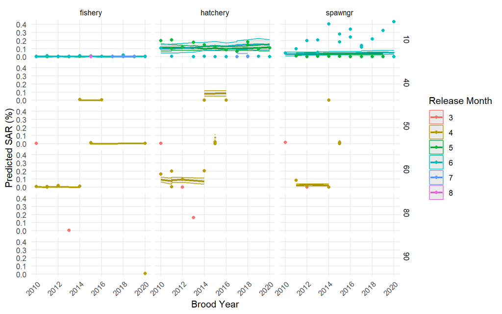

Figure 53: Predicted smolt-adult return generated from the model fit across fate, brood years, mean weight release groups, and release month.

**Tab 2**

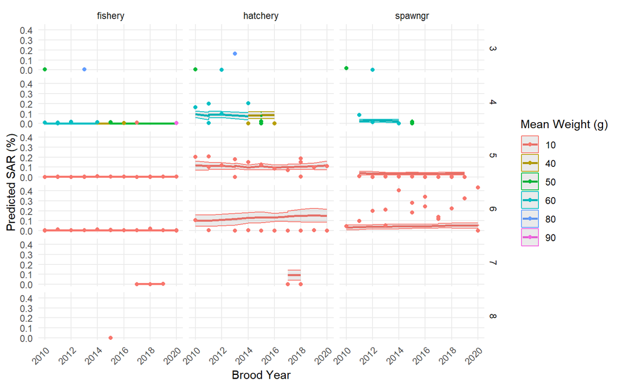

Figure 54: Predicted smolt-adult return generated from the model fit across fate, brood years, mean weight release groups, and release month.

**Tab 3**

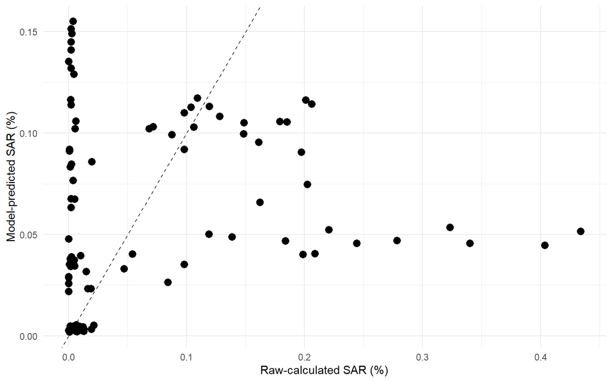

Figure 55: Raw-calculated vs. Model-predicted smolt-adult return generated from the model fit.

**Tab 4**

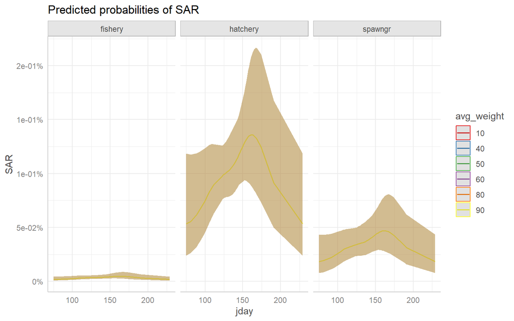

Figure 56: Marginal effects from the model fit showing how combined changes in mean weight at release and release timing (jday) affect smolt-adult-return across fates.

**Tab 1**

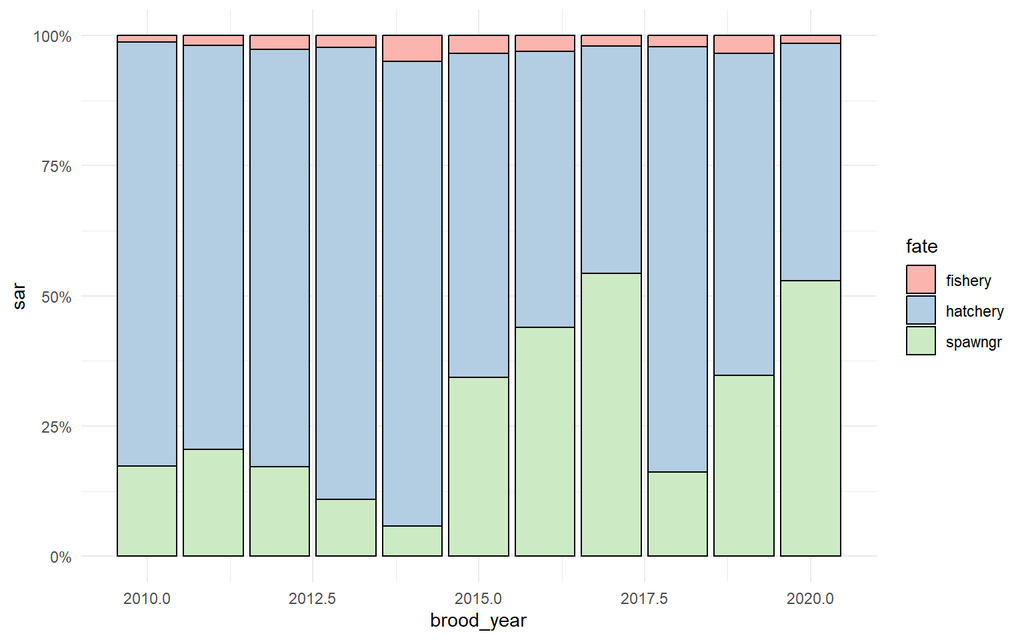

Figure 57: Proportion-at-fate of the calculated smolt-adult-return across brood years.

**Tab 2**